# SVM

Jang, Eunhee

2018년 6월 14일

SVM -> 분류 신경망 -> 분류, 회귀 logistic regression -> 분류

=> cost function(에러 함수)

### 알아야하는 것

1. 백터 (위치 벡터는 0부터 시작) vector의 덧셈 & 뺄셈 -> 그냥 점의 덧셈과 뺄셈 vector 의 곱셈(크기) -> 성분끼리 곱해서 더하기 -> 피타고라스(크기를 구할 때 사용하는 듯)

vector의 내적 ->

```
 |a| * |b| * cosθ == a * b -> scalar 크기
```

(수직일 때 0, 다른 방향 < 0 ) 직선의 방정식의 수직이 되는 직선(normal vector) -> a의 기울기 * b의 기울기 = -1

2. 미분 (ex, y = x^2 미분 -> y = 2x 직선)
3. 직선
4. logistic regression
5. SVM

### SVM알고리즘이란?

- 초평면을 이용한 분류 분류와 수치예측을 포함한 거의 모든 유형의 학습작업에 사용될 수 있게 정응이 된다. 알고리즘의 주요 성공은 대부분 패턴 인식의 번위로 들어온다.

#### 필기체 데이터 SVM 으로 분류 모델 생성하기

```r
# 1. 데이터 로드

letters <- read.csv("C:/data/letterdata.csv")

str(letters)
```

```
## 'data.frame':    20000 obs. of  17 variables:
##  $ letter: Factor w/ 26 levels "A","B","C","D",..: 20 9 4 14 7 19 2 1 10 13 ...
##  $ xbox  : int  2 5 4 7 2 4 4 1 2 11 ...
##  $ ybox  : int  8 12 11 11 1 11 2 1 2 15 ...
##  $ width : int  3 3 6 6 3 5 5 3 4 13 ...
##  $ height: int  5 7 8 6 1 8 4 2 4 9 ...
##  $ onpix : int  1 2 6 3 1 3 4 1 2 7 ...
##  $ xbar  : int  8 10 10 5 8 8 8 8 10 13 ...
##  $ ybar  : int  13 5 6 9 6 8 7 2 6 2 ...
##  $ x2bar : int  0 5 2 4 6 6 6 2 2 6 ...
##  $ y2bar : int  6 4 6 6 6 9 6 2 6 2 ...
##  $ xybar : int  6 13 10 4 6 5 7 8 12 12 ...
##  $ x2ybar: int  10 3 3 4 5 6 6 2 4 1 ...
##  $ xy2bar: int  8 9 7 10 9 6 6 8 8 9 ...
##  $ xedge : int  0 2 3 6 1 0 2 1 1 8 ...
##  $ xedgey: int  8 8 7 10 7 8 8 6 6 1 ...
##  $ yedge : int  0 4 3 2 5 9 7 2 1 1 ...
##  $ yedgex: int  8 10 9 8 10 7 10 7 7 8 ...
```

```r
# 2. 훈련 데이터와 테스터 데이터 구분

letters_train <- letters[1:16000, ]

letters_test  <- letters[16001:20000, ]

# 3. 데이터로 모델 훈련 ----

# 단순 선형 SVM을 훈련으로 시작

# install.packages("kernlab")

library(kernlab)
                     # knn와 svm과 섞임                             # vanilladot
letter_classifier <- ksvm(letter ~ ., data = letters_train, kernel = "vanilladot")
# 4. 모델에 대한 기본 정보 확인

# SV type: C-svc  (classification)
# parameter : cost C = 1
letter_classifier
```

```
## Support Vector Machine object of class "ksvm"
##
## SV type: C-svc  (classification)
##  parameter : cost C = 1
##
## Linear (vanilla) kernel function.
##
## Number of Support Vectors : 7037
##
## Objective Function Value : -14.1746 -20.0072 -23.5628 -6.2009 -7.5524 -32.7694 -49.9786 -18.1824 -62.1111 -32.7284 -16.2209 -32.2837 -28.9777 -51.2195 -13.276 -35.6217 -30.8612 -16.5256 -14.6811 -32.7475 -30.3219 -7.7956 -11.8138 -32.3463 -13.1262 -9.2692 -153.1654 -52.9678 -76.7744 -119.2067 -16…
## Training error : 0.130062
```

```r
# 5..모델 성능 평가 ----
# 테스트 데이터셋에 대한 예측

letter_predictions <- predict(letter_classifier, letters_test)

head(letter_predictions)
```

```
## [1] U N V X N H
## Levels: A B C D E F G H I J K L M N O P Q R S T U V W X Y Z
```

```r
table(letter_predictions, letters_test$letter)
```

```
##
## letter_predictions   A   B   C   D   E   F   G   H   I   J   K   L   M   N
##                  A 144   0   0   0   0   0   0   0   0   1   0   0   1   2
##                  B   0 121   0   5   2   0   1   2   0   0   1   0   1   0
##                  C   0   0 120   0   4   0  10   2   2   0   1   3   0   0
##                  D   2   2   0 156   0   1   3  10   4   3   4   3   0   5
##                  E   0   0   5   0 127   3   1   1   0   0   3   4   0   0
##                  F   0   0   0   0   0 138   2   2   6   0   0   0   0   0
##                  G   1   1   2   1   9   2 123   2   0   0   1   2   1   0
##                  H   0   0   0   1   0   1   0 102   0   2   3   2   3   4
##                  I   0   1   0   0   0   1   0   0 141   8   0   0   0   0
##                  J   0   1   0   0   0   1   0   2   5 128   0   0   0   0
##                  K   1   1   9   0   0   0   2   5   0   0 118   0   0   2
##                  L   0   0   0   0   2   0   1   1   0   0   0 133   0   0
##                  M   0   0   1   1   0   0   1   1   0   0   0   0 135   4
##                  N   0   0   0   0   0   1   0   1   0   0   0   0   0 145
##                  O   1   0   2   1   0   0   1   2   0   1   0   0   0   1
##                  P   0   0   0   1   0   2   1   0   0   0   0   0   0   0
##                  Q   0   0   0   0   0   0   8   2   0   0   0   3   0   0
##                  R   0   7   0   0   1   0   3   8   0   0  13   0   0   1
##                  S   1   1   0   0   1   0   3   0   1   1   0   1   0   0
##                  T   0   0   0   0   3   2   0   0   0   0   1   0   0   0
##                  U   1   0   3   1   0   0   0   2   0   0   0   0   0   0
##                  V   0   0   0   0   0   1   3   4   0   0   0   0   1   2
##                  W   0   0   0   0   0   0   1   0   0   0   0   0   2   0
##                  X   0   1   0   0   2   0   0   1   3   0   1   6   0   0
##                  Y   3   0   0   0   0   0   0   1   0   0   0   0   0   0
##                  Z   2   0   0   0   1   0   0   0   3   4   0   0   0   0
##
## letter_predictions   O   P   Q   R   S   T   U   V   W   X   Y   Z
##                  A   2   0   5   0   1   1   1   0   1   0   0   1
##                  B   0   2   2   3   5   0   0   2   0   1   0   0
##                  C   2   0   0   0   0   0   0   0   0   0   0   0
##                  D   5   3   1   4   0   0   0   0   0   3   3   1
##                  E   0   0   2   0  10   0   0   0   0   2   0   3
##                  F   0  16   0   0   3   0   0   1   0   1   2   0
##                  G   1   2   8   2   4   3   0   0   0   1   0   0
##                  H  20   0   2   3   0   3   0   2   0   0   1   0
##                  I   0   1   0   0   3   0   0   0   0   5   1   1
##                  J   1   1   3   0   2   0   0   0   0   1   0   6
##                  K   0   1   0   7   0   1   3   0   0   5   0   0
##                  L   0   0   1   0   5   0   0   0   0   0   0   1
##                  M   0   0   0   0   0   0   3   0   8   0   0   0
##                  N   0   0   0   3   0   0   1   0   2   0   0   0
##                  O  99   3   3   0   0   0   3   0   0   0   0   0
##                  P   2 130   0   0   0   0   0   0   0   0   1   0
##                  Q   3   1 124   0   5   0   0   0   0   0   2   0
##                  R   1   1   0 138   0   1   0   1   0   0   0   0
##                  S   0   0  14   0 101   3   0   0   0   2   0  10
##                  T   0   0   0   0   3 133   1   0   0   0   2   2
##                  U   1   0   0   0   0   0 152   0   0   1   1   0
##                  V   1   0   3   1   0   0   0 126   1   0   4   0
##                  W   0   0   0   0   0   0   4   4 127   0   0   0
##                  X   1   0   0   0   1   0   0   0   0 137   1   1
##                  Y   0   7   0   0   0   3   0   0   0   0 127   0
##                  Z   0   0   0   0  18   3   0   0   0   0   0 132
```

```r
# 6. 일치/불일치 예측을 표시하는 TRUE/FALSE 벡터 생성

agreement <- letter_predictions == letters_test$letter

table(agreement)
```

```
## agreement
## FALSE  TRUE
##   643  3357
```

```r
prop.table(table(agreement))
```

```
## agreement
##   FALSE    TRUE
## 0.16075 0.83925
```

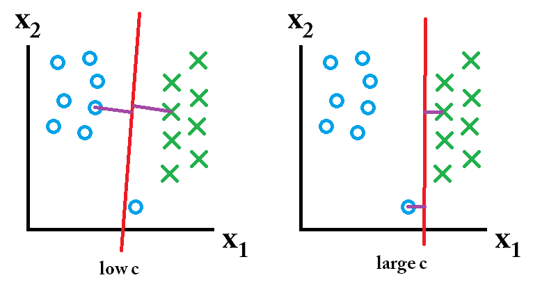

> support vector란 , 분류선과의 margin에 위치한 data로 이 margin을 충분히 갖는 것이 SVM의 목표

#### SVM 문제. 한국인 신체 데이터를 가지고 SVM 분류 모델을 생성하시오 (은성이 정리)

```r
# 1. 워킹디렉토리 소환

library(e1071)

# 2. 데이터 로드

body <- read.csv("C:/data/kbody2.csv", header = F)


# 3. na값 제거

body1 <- na.omit(body)

# 4.컬럼명 줌

colnames(body1) <- c("gender", "age", "height", "chest", "heory", "bae", "ass", "kyeo",
                     "face_vertical", "head", "bone", "body_fat", "body_water",
                     "protein", "mineral", "body_fat_per", "bae_fat_per", "work", "bae_fat_test", "work_test")

# 5. 랜덤시드 생성

set.seed(12345)
body_ran <- body1[order(runif(12894)), ]
body_train <- body_ran[1:10314, ]
body_test <- body_ran[10315:12894, ]


# 6. 선형SVM 훈련

body_svm <- svm(work_test~., data = body_train, kernel="linear")
body_svm
```

```
##
## Call:
## svm(formula = work_test ~ ., data = body_train, kernel = "linear")
##
##
## Parameters:
##    SVM-Type:  C-classification
##  SVM-Kernel:  linear
##        cost:  1
##       gamma:  0.04347826
##
## Number of Support Vectors:  1944
```

```r
##
## Call:
## svm(formula = work_test ~ ., data = body_train, kernel = "linear")
##
##
## Parameters:
##    SVM-Type:  C-classification
##  SVM-Kernel:  linear
##        cost:  1
##       gamma:  0.04347826
##
## Number of Support Vectors:  1944


# 7. 모델 테스트

p <- predict(body_svm, body_test, type="class")
p
```

[output not shown]

[output cut: 376 more lines]

[output not shown]

```r
# 8. 정확도를 확인한다.
agreement <- p == body_test$work_test
table(agreement)
```

```
## agreement
## FALSE  TRUE
##   150  2430
```

```r
prop.table(table(agreement))
```

```
## agreement
##      FALSE       TRUE
## 0.05813953 0.94186047
```

#### 문제352. swm머신러닝 함수로 알파벳 데이터 분류 모델을 생성하고 테스트 데이터의 정확도가 어떻게 나오는지 확인하시오.

```r
# 3. 데이터로 모델 훈련 ----

# 단순 선형 SVM을 훈련으로 시작

letter_classifier <- svm(letter ~ ., data = letters_train, kernel = "linear")


# 4. 모델에 대한 기본 정보 확인

letter_classifier
```

```
##
## Call:
## svm(formula = letter ~ ., data = letters_train, kernel = "linear")
##
##
## Parameters:
##    SVM-Type:  C-classification
##  SVM-Kernel:  linear
##        cost:  1
##       gamma:  0.0625
##
## Number of Support Vectors:  7035
```

```r
# 5..모델 성능 평가 ----
# 테스트 데이터셋에 대한 예측

letter_predictions <- predict(letter_classifier, letters_test)

head(letter_predictions)
```

```
## 16001 16002 16003 16004 16005 16006
##     U     N     V     X     N     H
## Levels: A B C D E F G H I J K L M N O P Q R S T U V W X Y Z
```

```r
table(letter_predictions, letters_test$letter)
```

```
##
## letter_predictions   A   B   C   D   E   F   G   H   I   J   K   L   M   N
##                  A 143   0   0   0   0   0   0   0   0   1   0   0   1   2
##                  B   1 119   0   5   1   0   1   2   0   0   0   0   1   0
##                  C   0   0 119   0   4   0   8   1   2   0   1   3   0   0
##                  D   2   2   0 156   0   1   3  10   4   3   4   3   0   5
##                  E   0   0   5   0 124   2   0   0   0   0   2   4   0   0
##                  F   0   0   0   0   0 134   1   1   5   0   0   0   0   0
##                  G   1   2   3   1  11   2 126   3   0   0   1   2   1   0
##                  H   0   0   0   1   0   0   0  99   0   1   3   2   3   3
##                  I   0   1   0   0   0   3   0   0 142   9   0   0   0   0
##                  J   0   1   0   0   0   2   0   2   5 128   0   0   0   0
##                  K   1   0   8   0   0   0   2   5   0   0 115   0   0   1
##                  L   0   0   0   0   2   0   1   1   0   0   0 132   0   0
##                  M   0   0   1   1   0   0   1   2   0   0   0   0 134   3
##                  N   0   0   0   0   0   2   0   1   0   0   0   0   1 148
##                  O   1   0   2   1   0   0   1   3   0   1   1   0   0   1
##                  P   0   0   0   1   0   2   1   0   0   0   0   0   0   0
##                  Q   0   0   0   0   0   0   8   1   0   0   0   0   0   0
##                  R   0   8   0   0   1   0   3   9   0   0  13   0   0   1
##                  S   1   2   0   0   2   0   4   0   1   1   3   5   0   0
##                  T   0   0   1   0   4   4   0   2   0   0   1   0   0   0
##                  U   1   0   3   1   0   0   0   2   0   0   0   0   0   0
##                  V   0   0   0   0   0   1   3   4   0   0   0   0   1   2
##                  W   0   0   0   0   0   0   1   0   0   0   0   0   2   0
##                  X   0   1   0   0   2   0   0   2   3   0   2   6   0   0
##                  Y   3   0   0   0   0   0   0   1   0   0   0   0   0   0
##                  Z   2   0   0   0   1   0   0   0   3   4   0   0   0   0
##
## letter_predictions   O   P   Q   R   S   T   U   V   W   X   Y   Z
##                  A   2   0   5   0   0   1   1   0   1   0   0   1
##                  B   0   1   1   3   3   0   0   2   0   1   0   0
##                  C   1   0   0   0   0   0   0   0   0   0   0   0
##                  D   5   3   1   4   0   0   0   0   0   3   2   1
##                  E   0   0   0   0   6   0   0   0   0   0   0   2
##                  F   0  14   0   0   4   0   0   1   0   1   2   0
##                  G   1   3   8   2   4   2   0   0   0   1   0   0
##                  H  17   0   2   3   0   1   0   2   0   0   1   0
##                  I   0   1   0   0   3   0   0   0   0   5   1   1
##                  J   2   1   3   0   0   0   0   0   0   1   0   5
##                  K   0   1   0   6   0   1   3   0   0   5   0   0
##                  L   0   0   1   0   3   0   0   0   0   0   0   0
##                  M   0   0   0   0   0   0   3   0   8   0   0   0
##                  N   0   0   0   3   0   0   1   0   2   0   0   0
##                  O 101   3   3   0   0   0   3   0   0   0   0   0
##                  P   2 130   0   0   0   0   0   0   0   0   1   0
##                  Q   3   1 124   0   4   0   0   0   0   0   1   0
##                  R   1   1   0 139   0   0   0   1   0   0   0   0
##                  S   0   2  17   0 111   3   0   0   0   2   0  13
##                  T   1   0   0   0   3 137   1   0   0   0   3   2
##                  U   1   0   0   0   0   0 151   0   0   0   1   0
##                  V   0   0   3   0   0   0   0 126   1   0   5   0
##                  W   1   0   0   0   0   0   5   4 127   0   0   0
##                  X   1   0   0   1   2   0   0   0   0 140   1   1
##                  Y   0   7   0   0   0   3   0   0   0   0 127   0
##                  Z   0   0   0   0  18   3   0   0   0   0   0 132
```

```r
# 6. 일치/불일치 예측을 표시하는 TRUE/FALSE 벡터 생성

agreement <- letter_predictions == letters_test$letter

table(agreement)
```

```
## agreement
## FALSE  TRUE
##   636  3364
```

```r
prop.table(table(agreement))
```

```
## agreement
## FALSE  TRUE
## 0.159 0.841
```

#### R 에서 mnist 로 필기체 인식 학습시키는 코드

```r
# 1. 필요한 패키지를 로드한다.

# install.packages("caret")
#
# install.packages("doParallel")
#
# install.packages("kernlab")
#
# install.packages("ggplot2")
#
# install.packages("lattice")

library(ggplot2)
library(lattice)

library(kernlab)

library(caret)

library(doParallel)
# 2. 병렬 작업을 할 수 있도록 설정한다.

cl <- makeCluster(detectCores())

registerDoParallel(cl)


# 3.  28행의 28열의 행렬의 필기체 데이터 6만개를 사용한다.


# Load the MNIST digit recognition dataset into R

# http://yann.lecun.com/exdb/mnist/

# assume you have all 4 files and gunzip'd them

# creates train$n, train$x, train$y  and test$n, test$x, test$y

# e.g. train$x is a 60000 x 784 matrix, each row is one digit (28x28)

# call:  show_digit(train$x[5,])   to see a digit.

# brendan o'connor - gist.github.com/39760 - anyall.org



# 4.  필기체 데이터 불러오는 함수이다.

load_mnist <- function() {

  load_image_file <- function(filename) {

    ret = list()

    f = file(filename,'rb')

    readBin(f,'integer',n=1,size=4,endian='big')

    ret$n = readBin(f,'integer',n=1,size=4,endian='big')

    nrow = readBin(f,'integer',n=1,size=4,endian='big')

    ncol = readBin(f,'integer',n=1,size=4,endian='big')

    x = readBin(f,'integer',n=ret$n*nrow*ncol,size=1,signed=F)

    ret$x = matrix(x, ncol=nrow*ncol, byrow=T)

    close(f)

    ret

  }

  load_label_file <- function(filename) {

    f = file(filename,'rb')

    readBin(f,'integer',n=1,size=4,endian='big')

    n = readBin(f,'integer',n=1,size=4,endian='big')

    y = readBin(f,'integer',n=n,size=1,signed=F)

    close(f)

    y

  }

  train <<- load_image_file('C:/data/train-images.idx3-ubyte')

  test <<- load_image_file('C:/data/t10k-images.idx3-ubyte')



  train$y <<- load_label_file('C:/data/train-labels.idx1-ubyte')

  test$y <<- load_label_file('C:/data/t10k-labels.idx1-ubyte')

}


# 5. 필기체 데이터중 하나를 시각화 하는 함수이다.

show_digit <- function(arr784, col=gray(12:1/12), ...) {

  image(matrix(arr784, nrow=28)[,28:1], col=col, ...)

}

# 6. 데이터를 로드한다.


train <- data.frame()

test <- data.frame()


# Load data.


load_mnist()


# Normalize: X = (X - min) / (max - min) => X = (X - 0) / (255 - 0) => X = X / 255.


train$x <- train$x / 255


# 7. 훈련 데이터와 테스트 데이터를 6 대 4로 나눈다.
# Setup training data with digit and pixel values with 60/40 split for train/cv.


inTrain = data.frame(y=train$y, train$x)

inTrain$y <- as.factor(inTrain$y)

trainIndex = createDataPartition(inTrain$y, p = 0.60,list=FALSE)

training = inTrain[trainIndex,]
nrow(training)
```

```
## [1] 36004
```

```r
cv = inTrain[-trainIndex,]


# 8. svm 모델로 훈련시킨다.

# SVM. 95/94.

fit <- train(y ~ ., data = head(training, 1000), method = 'svmRadial', tuneGrid = data.frame(sigma=0.0107249, C=1))
# C? swm분류선을 정하는 파라미터, overfitting / underfitting 막기
# sigma? svm커널을 적용해서 space를 변경할 때 발생하는 overfitting을 조정하는 파라미터
  # (space를 변경한다는 것은 비선형 --> 선형으로 변경)
results <- predict(fit, newdata = head(cv, 1000))

results
```

[output not shown]

[output cut: 16 more lines]

```r
confusionMatrix(results, head(cv$y, 1000))
```

```
## Confusion Matrix and Statistics
##
##           Reference
## Prediction   0   1   2   3   4   5   6   7   8   9
##          0  83   0   1   0   0   0   0   2   0   0
##          1   0 116   0   0   1   0   1   2   4   0
##          2   0   0  98   2   3   1   1   2   3   0
##          3   0   0   1  81   0   1   0   0   3   3
##          4   0   0   0   0 100   0   2   1   0   3
##          5   2   1   1   4   0  81   1   0   1   0
##          6   1   0   3   0   0   2  95   0   1   0
##          7   0   1   1   1   0   0   0 114   0   4
##          8   0   0   0   1   0   0   0   0  74   0
##          9   0   0   0   1   3   1   0   3   3  85
##
## Overall Statistics
##
##                Accuracy : 0.927
##                  95% CI : (0.9091, 0.9423)
##     No Information Rate : 0.124
##     P-Value [Acc > NIR] : < 2.2e-16
##
##                   Kappa : 0.9187
##  Mcnemar's Test P-Value : NA
##
## Statistics by Class:
##
##                      Class: 0 Class: 1 Class: 2 Class: 3 Class: 4 Class: 5
## Sensitivity            0.9651   0.9831   0.9333   0.9000   0.9346   0.9419
## Specificity            0.9967   0.9909   0.9866   0.9912   0.9933   0.9891
## Pos Pred Value         0.9651   0.9355   0.8909   0.9101   0.9434   0.8901
## Neg Pred Value         0.9967   0.9977   0.9921   0.9901   0.9922   0.9945
## Prevalence             0.0860   0.1180   0.1050   0.0900   0.1070   0.0860
## Detection Rate         0.0830   0.1160   0.0980   0.0810   0.1000   0.0810
## Detection Prevalence   0.0860   0.1240   0.1100   0.0890   0.1060   0.0910
## Balanced Accuracy      0.9809   0.9870   0.9600   0.9456   0.9639   0.9655
##                      Class: 6 Class: 7 Class: 8 Class: 9
## Sensitivity            0.9500   0.9194   0.8315   0.8947
## Specificity            0.9922   0.9920   0.9989   0.9878
## Pos Pred Value         0.9314   0.9421   0.9867   0.8854
## Neg Pred Value         0.9944   0.9886   0.9838   0.9889
## Prevalence             0.1000   0.1240   0.0890   0.0950
## Detection Rate         0.0950   0.1140   0.0740   0.0850
## Detection Prevalence   0.1020   0.1210   0.0750   0.0960
## Balanced Accuracy      0.9711   0.9557   0.9152   0.9413
```

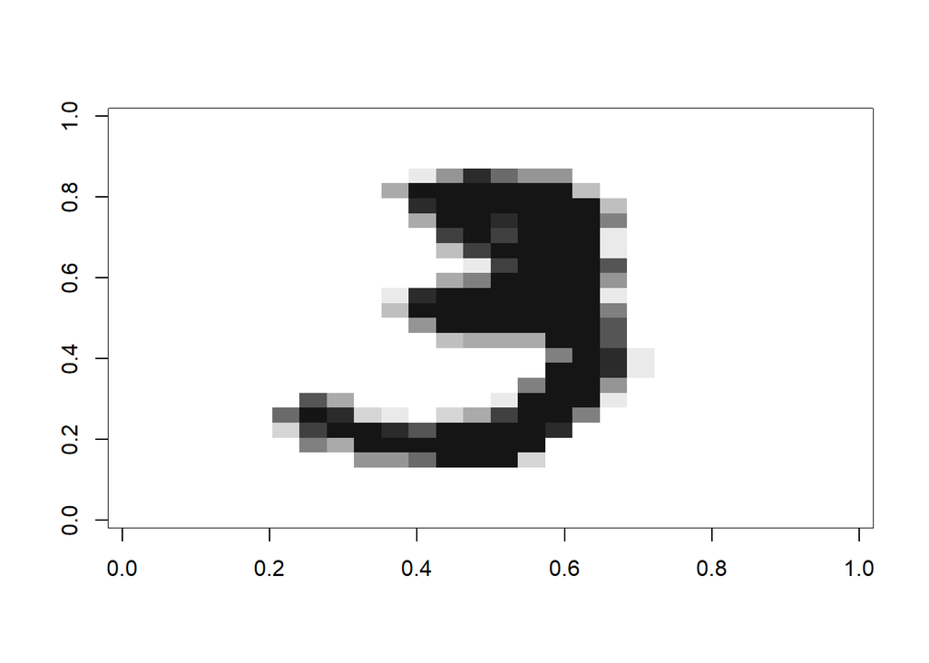

```r
# 9. 만든  svm 모델이 필기체 데이터를 잘 맞추는지 확인한다.

show_digit(as.matrix(training[5,2:785]))
```

```r
# Predict the digit.

predict(fit, newdata = training[5,])
```

```
## [1] 3
## Levels: 0 1 2 3 4 5 6 7 8 9
```

```r
# Check the actual answer for the digit.

training[5,1]
```

```
## [1] 3
## Levels: 0 1 2 3 4 5 6 7 8 9
```

#### 문제353. 알파벳 데이터를 ksvm함수를 사용할 때 정확도는 84%였다. train함수를 이용해서 알파벳 데이터의 정확도를 90%이상 올리시오

```r
# 1. 데이터 로드

letters <- read.csv("C:/data/letterdata.csv")

str(letters)
```

```
## 'data.frame':    20000 obs. of  17 variables:
##  $ letter: Factor w/ 26 levels "A","B","C","D",..: 20 9 4 14 7 19 2 1 10 13 ...
##  $ xbox  : int  2 5 4 7 2 4 4 1 2 11 ...
##  $ ybox  : int  8 12 11 11 1 11 2 1 2 15 ...
##  $ width : int  3 3 6 6 3 5 5 3 4 13 ...
##  $ height: int  5 7 8 6 1 8 4 2 4 9 ...
##  $ onpix : int  1 2 6 3 1 3 4 1 2 7 ...
##  $ xbar  : int  8 10 10 5 8 8 8 8 10 13 ...
##  $ ybar  : int  13 5 6 9 6 8 7 2 6 2 ...
##  $ x2bar : int  0 5 2 4 6 6 6 2 2 6 ...
##  $ y2bar : int  6 4 6 6 6 9 6 2 6 2 ...
##  $ xybar : int  6 13 10 4 6 5 7 8 12 12 ...
##  $ x2ybar: int  10 3 3 4 5 6 6 2 4 1 ...
##  $ xy2bar: int  8 9 7 10 9 6 6 8 8 9 ...
##  $ xedge : int  0 2 3 6 1 0 2 1 1 8 ...
##  $ xedgey: int  8 8 7 10 7 8 8 6 6 1 ...
##  $ yedge : int  0 4 3 2 5 9 7 2 1 1 ...
##  $ yedgex: int  8 10 9 8 10 7 10 7 7 8 ...
```

```r
# 2. 훈련 데이터와 테스터 데이터 구분

training <- letters[1:16000, ]

letters_test  <- letters[16001:20000, ]


# 3. 데이터로 모델 훈련 ----

# 단순 선형 SVM을 훈련으로 시작

# install.packages("kernlab")

library(kernlab)

letter_classifier <- ksvm(letter ~ ., data = letters_train, kernel = "rbfdot", C=1.5)


# 4. 모델에 대한 기본 정보 확인

# SV type: C-svc  (classification)
# parameter : cost C = 1
letter_classifier
```

```
## Support Vector Machine object of class "ksvm"
##
## SV type: C-svc  (classification)
##  parameter : cost C = 1.5
##
## Gaussian Radial Basis kernel function.
##  Hyperparameter : sigma =  0.0471687227989854
##
## Number of Support Vectors : 8082
##
## Objective Function Value : -48.9858 -40.3769 -66.8328 -29.7053 -38.9816 -53.0842 -77.6699 -45.1044 -81.1791 -59.409 -49.7616 -70.6208 -75.1001 -55.4149 -38.9625 -51.962 -66.0681 -47.8782 -46.0839 -73.8266 -56.9497 -42.9755 -46.5554 -64.4511 -46.1105 -40.6813 -204.4017 -134.861 -118.1036 -139.0049…
## Training error : 0.040813
```

```r
# 5..모델 성능 평가 ----
# 테스트 데이터셋에 대한 예측

letter_predictions <- predict(letter_classifier, letters_test)

# head(letter_predictions)
table(letter_predictions, letters_test$letter)
```

```
##
## letter_predictions   A   B   C   D   E   F   G   H   I   J   K   L   M   N
##                  A 151   0   0   0   0   0   0   0   0   0   0   0   0   0
##                  B   0 129   0   2   0   1   0   2   0   0   1   1   1   1
##                  C   0   0 133   0   3   0   1   0   2   0   0   1   0   0
##                  D   1   1   0 163   0   0   2   6   2   2   1   0   0   2
##                  E   0   0   2   0 139   2   0   0   0   2   0   4   0   0
##                  F   0   0   0   0   0 149   0   0   1   0   0   0   0   0
##                  G   0   0   2   0   6   0 154   2   0   0   0   2   1   0
##                  H   0   1   0   1   0   1   1 128   0   0   2   1   0   3
##                  I   0   0   0   0   0   0   0   0 153   1   0   0   0   0
##                  J   0   0   0   0   0   0   0   0   4 140   0   0   0   0
##                  K   0   0   1   0   0   0   0   4   0   0 134   0   0   1
##                  L   0   0   0   0   0   0   1   0   0   0   0 143   0   0
##                  M   0   0   0   0   0   0   1   1   0   0   0   0 141   3
##                  N   0   0   0   0   0   0   0   0   0   0   0   0   0 151
##                  O   0   0   3   0   0   0   1   0   0   1   0   0   0   3
##                  P   0   0   0   0   0   0   0   0   1   0   0   0   0   0
##                  Q   0   0   0   0   0   0   0   1   0   0   0   0   0   0
##                  R   0   2   0   1   0   0   2   5   0   0   6   1   0   1
##                  S   0   2   0   0   0   0   0   0   1   1   0   0   0   0
##                  T   0   0   0   0   0   0   0   0   0   0   0   0   0   0
##                  U   0   0   1   0   0   0   0   1   0   0   0   0   0   0
##                  V   0   0   0   0   0   0   0   0   0   0   0   0   0   1
##                  W   0   0   0   0   0   0   1   0   0   0   0   0   1   0
##                  X   0   1   0   0   0   0   0   0   0   0   2   4   0   0
##                  Y   4   0   0   0   0   0   0   1   0   0   0   0   0   0
##                  Z   0   0   0   0   4   0   0   0   1   1   0   0   0   0
##
## letter_predictions   O   P   Q   R   S   T   U   V   W   X   Y   Z
##                  A   0   0   2   0   0   1   0   0   0   0   0   1
##                  B   1   2   1   1   2   0   0   3   1   1   0   0
##                  C   0   0   0   0   0   0   0   0   0   0   0   0
##                  D   1   2   1   4   0   2   0   0   0   2   3   0
##                  E   0   0   0   0   1   0   0   0   0   0   0   2
##                  F   0  12   0   0   1   0   0   1   0   0   0   0
##                  G   1   1   1   0   0   1   0   0   0   0   0   0
##                  H   0   1   1   0   0   1   0   1   0   0   0   0
##                  I   0   0   0   0   0   0   0   0   0   1   0   0
##                  J   0   0   0   0   0   0   0   0   0   0   0   2
##                  K   0   0   0   3   0   0   0   0   0   2   0   0
##                  L   0   0   0   0   1   0   0   0   0   0   0   0
##                  M   0   0   0   0   0   0   1   0   2   0   0   0
##                  N   0   0   0   2   0   0   0   0   1   0   0   0
##                  O 130   2   3   0   0   0   1   0   0   0   0   0
##                  P   0 146   0   0   0   0   0   0   0   0   0   0
##                  Q   4   1 159   0   0   0   0   0   0   0   0   0
##                  R   1   1   0 151   0   1   0   0   0   0   0   0
##                  S   0   0   0   0 155   0   0   0   0   0   0   2
##                  T   0   0   0   0   0 143   0   0   0   0   1   0
##                  U   0   0   0   0   0   0 162   0   0   0   1   0
##                  V   0   0   0   0   0   0   2 131   0   0   1   0
##                  W   1   0   0   0   0   0   2   0 135   0   0   0
##                  X   0   0   0   0   1   1   0   0   0 153   1   1
##                  Y   0   0   0   0   0   1   0   0   0   0 138   0
##                  Z   0   0   0   0   0   0   0   0   0   0   0 150
```

```r
# 6. 일치/불일치 예측을 표시하는 TRUE/FALSE 벡터 생성

agreement <- letter_predictions == letters_test$letter

table(agreement)
```

```
## agreement
## FALSE  TRUE
##   239  3761
```

```r
prop.table(table(agreement))
```

```
## agreement
##   FALSE    TRUE
## 0.05975 0.94025
```